# AmpGram

### Positive dataset

- Sequences from dbAMP: **12389**
- Selected those with experimental evidence: **4271**
- Removed those with non-standard amino acids (153): **4118**
- Homology reduction with CD-HIT (90%): **2463**

### Benchmark, training and testing dataset

- Sequences were divided into **5 length groups** of equal sizes: [11:19], (19,26], (26,36], (36,60], (60,710]
- Benchmark dataset was created by selecting 1/10 of sequences from each length group: **494 sequences** (247 pos + 247 neg)
- The rest of sequences comprise train-test dataset **4432 sequences** (2216 pos + 2216 neg)

### Dataframe of mers

- All peptides are divided into 5 folds and cut into 10-mers: **87716 AMP mers** and **87599 non-AMP mers**

### Counting n-grams

- Generation and counting of n-grams

### Cross validation

- 5-fold cross validation

### Prediction results

- Fraction of positive mers decreases with length of the peptide

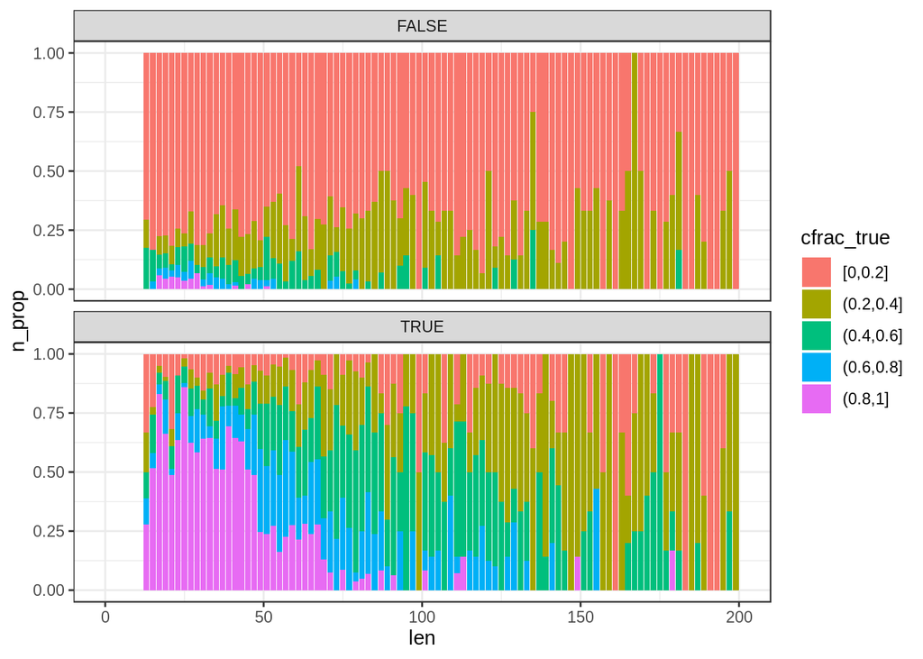

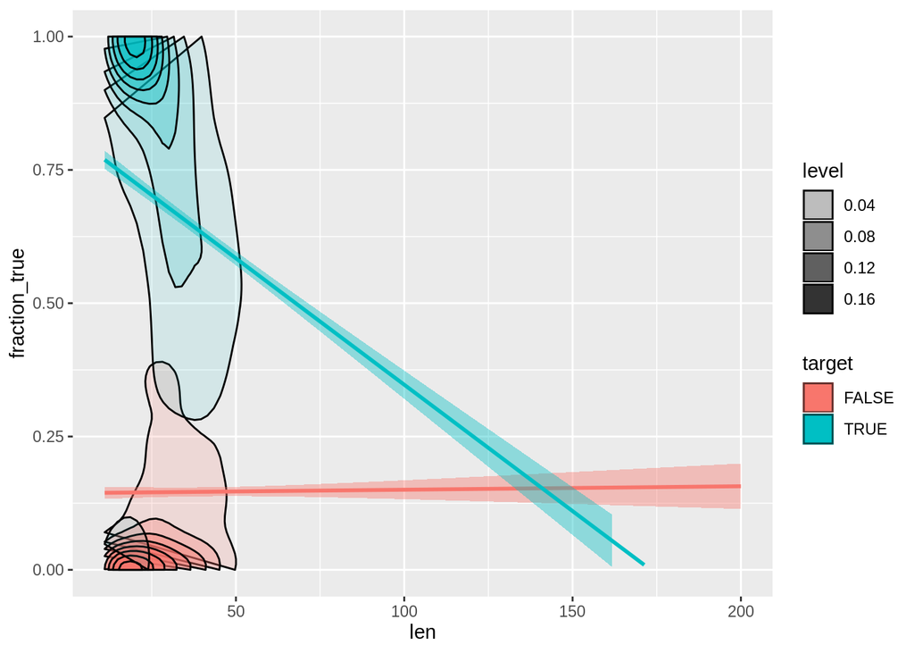

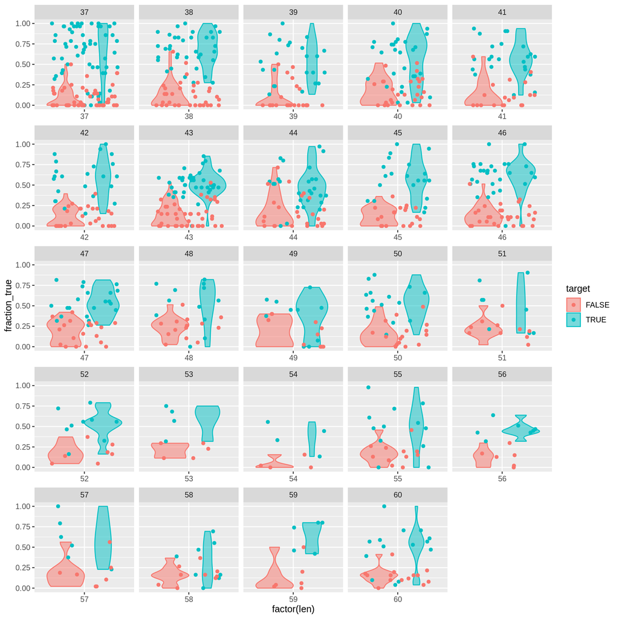

20 randomly selected peptides from length group (36,60]

- Some non-AMP peptides possess fragments of sequences predicted as positive.

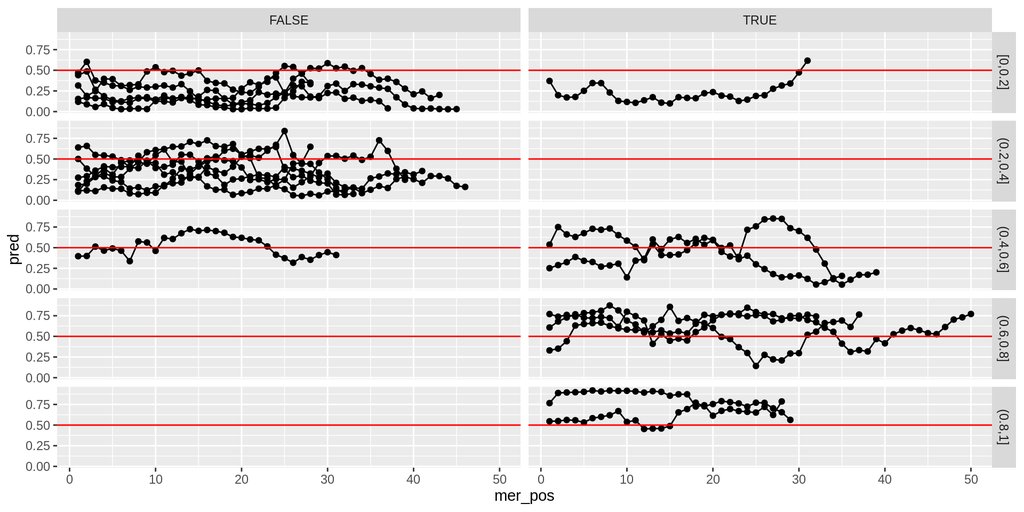

20 randomly selected peptides from length group (26,36]

- Some non-AMP peptides have very high fraction of positive mers.

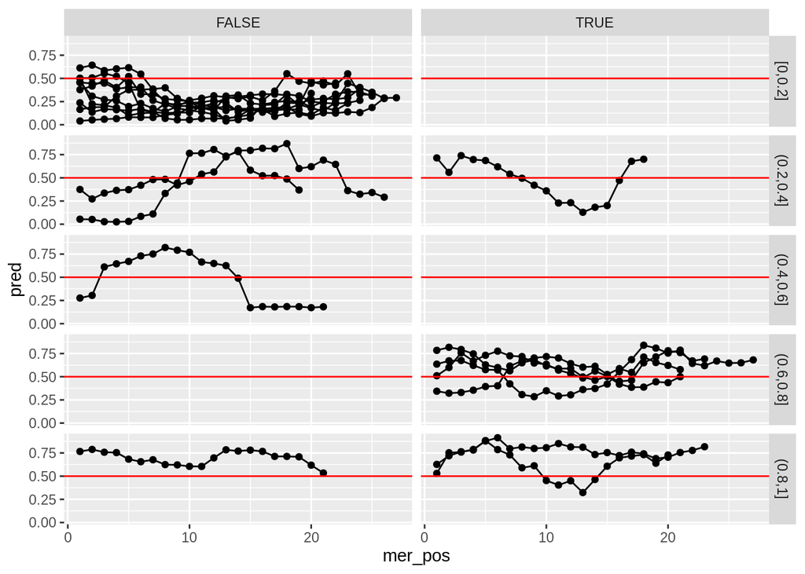

### Statistics for the second layer of prediction

Following statistics are calculated for each peptide:

- fraction_true - fraction of positive mers,
- pred_mean - mean value of prediction,
- pred_median - median of prediction,
- n_peptide - number of mers in a peptide,
- n_pos - number of positive mers,
- pred_min - minimum value of prediction,
- pred_max - maximum value of prediction,
- longest_pos - the longest stretch of mers occuring consecutively and predicted as positive,
- n_pos_10 - number of streches comprising of at least 10 mers predicted as positive,
- frac_0_0.2 - fraction of mers with prediction in range [0,0.2],
- frac_0.2_0.4 - fraction of mers with prediction in range (0.2,0.4],
- frac_0.4_0.6 - fraction of mers with prediction in range (0.4,0.6],
- frac_0.6_0.8 - fraction of mers with prediction in range (0.6,0.8],
- frac_0.8_1 - fraction of mers with prediction in range (0.8,1]).

### Second layer - random forest

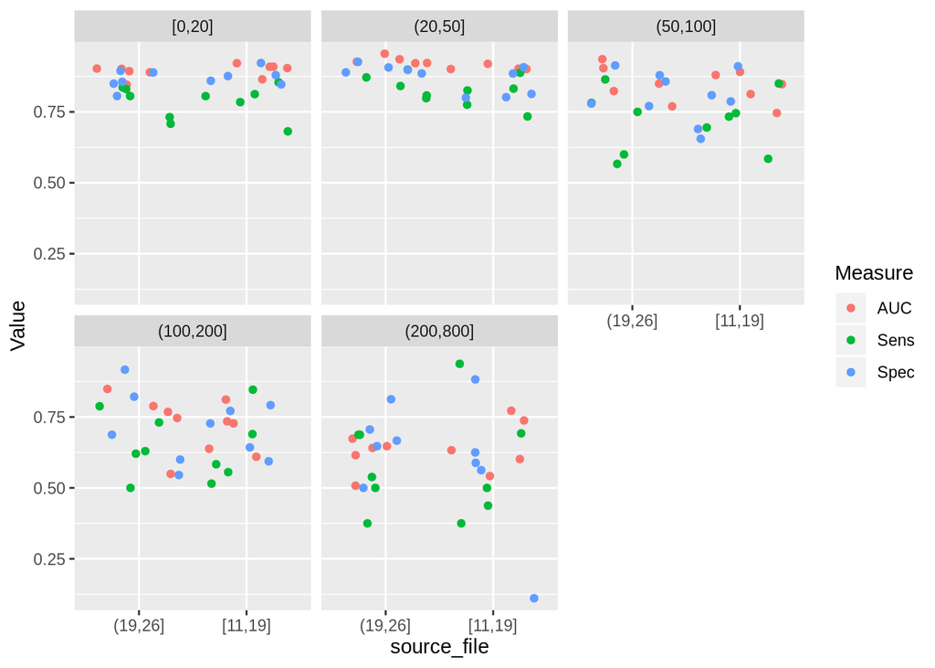

### Second layer - other algorithms

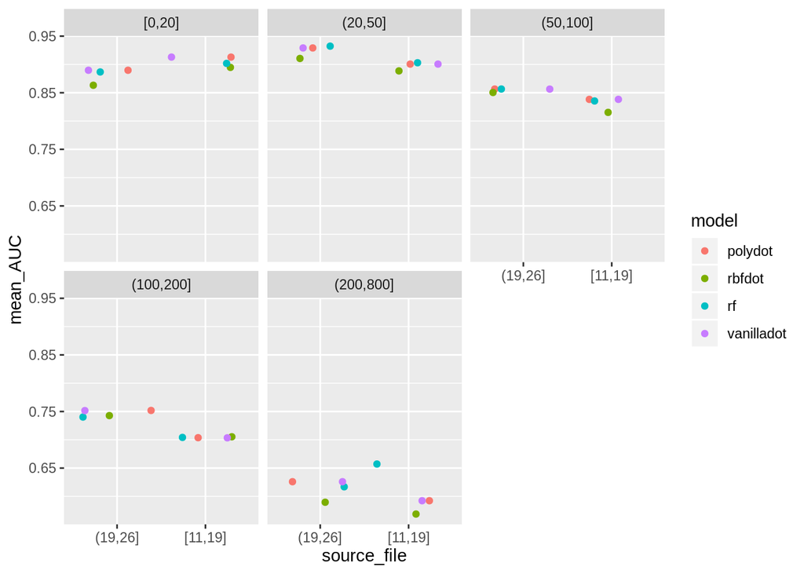